# Bellabeat Case Study using R

Braeden Davidson

2023-02-04

# About the company

Bellabeat, a high-tech manufacturer of health-focused products for women. Bellabeat is a successful small company, but they have the potential to become a larger player in the global smart device market. Urška Sršen, cofounder and Chief Creative Officer of Bellabeat, believes that analyzing smart device fitness data could help unlock new growth opportunities for the company.

# Questions to Guide Analysis

1. What are some trends in smart device usage?
2. How could these trends apply to Bellabeat customers?
3. How could these trends help influence Bellabeat marketing strategy?

# Business task

Identify potential opportunities for growth and recommendations for the Bellabeat marketing strategy improvement based on trends in smart device usage.

# Data sources

## Is Data ROCCC?

The data integrity and credibility is clearly insufficient to provide reliable and comprehensive insights to Bellabeat. Therefore, the following analysis can only provide first hints and directions which should be verified through an analysis of a larger and much more reliable dataset.

# Tools Used

For this analysis, I have chosen to use R due to the usability of the R markdown document, on RStudio/Posit Cloud.

# Loading packages

I will start by installing “Janitor” and all the “Tidyverse” R packages.

```r
install.packages('tidyverse')
install.packages("janitor")
```

Then I will load the required R packages for my analysis using the library(package) command.

```r
library(tidyverse)
library(lubridate)
```

```r
library(dplyr)
library(ggplot2)
library(tidyr)
library(janitor)
```

# Importing the datasets

For my analysis i’ll be using these three datasets: *dailyActivity_merged.csv* sleepDay_merged.csv *weightLogInfo_merged.csv

```r
activity <- read.csv("dailyActivity_merged.csv")
sleep <- read.csv("sleepDay_merged.csv")
weight <- read.csv("weightLogInfo_merged.csv")
```

I already checked the data in Google Sheets. I just need to make sure that everything was imported correctly by using head() function. The head() function in R Language is used to get the first parts of a vector, matrix, table, data frame or function.

```r
head(sleep)
```

```
##           Id              SleepDay TotalSleepRecords TotalMinutesAsleep
## 1 1503960366 4/12/2016 12:00:00 AM                 1                327
## 2 1503960366 4/13/2016 12:00:00 AM                 2                384
## 3 1503960366 4/15/2016 12:00:00 AM                 1                412
## 4 1503960366 4/16/2016 12:00:00 AM                 2                340
## 5 1503960366 4/17/2016 12:00:00 AM                 1                700
## 6 1503960366 4/19/2016 12:00:00 AM                 1                304
##   TotalTimeInBed
## 1            346
## 2            407
## 3            442
## 4            367
## 5            712
## 6            320
```

```r
head(activity)
```

```
##           Id ActivityDate TotalSteps TotalDistance TrackerDistance
## 1 1503960366    4/12/2016      13162          8.50            8.50
## 2 1503960366    4/13/2016      10735          6.97            6.97
## 3 1503960366    4/14/2016      10460          6.74            6.74
## 4 1503960366    4/15/2016       9762          6.28            6.28
## 5 1503960366    4/16/2016      12669          8.16            8.16
## 6 1503960366    4/17/2016       9705          6.48            6.48
##   LoggedActivitiesDistance VeryActiveDistance ModeratelyActiveDistance
## 1                        0               1.88                     0.55
## 2                        0               1.57                     0.69
## 3                        0               2.44                     0.40
## 4                        0               2.14                     1.26
## 5                        0               2.71                     0.41
## 6                        0               3.19                     0.78
##   LightActiveDistance SedentaryActiveDistance VeryActiveMinutes
## 1                6.06                       0                25
## 2                4.71                       0                21
## 3                3.91                       0                30
## 4                2.83                       0                29
## 5                5.04                       0                36
## 6                2.51                       0                38
##   FairlyActiveMinutes LightlyActiveMinutes SedentaryMinutes Calories
## 1                  13                  328              728     1985
## 2                  19                  217              776     1797
## 3                  11                  181             1218     1776
## 4                  34                  209              726     1745
## 5                  10                  221              773     1863
## 6                  20                  164              539     1728
```

```r
head(weight)
```

```
##           Id                  Date WeightKg WeightPounds Fat   BMI
## 1 1503960366  5/2/2016 11:59:59 PM     52.6     115.9631  22 22.65
## 2 1503960366  5/3/2016 11:59:59 PM     52.6     115.9631  NA 22.65
## 3 1927972279  4/13/2016 1:08:52 AM    133.5     294.3171  NA 47.54
## 4 2873212765 4/21/2016 11:59:59 PM     56.7     125.0021  NA 21.45
## 5 2873212765 5/12/2016 11:59:59 PM     57.3     126.3249  NA 21.69
## 6 4319703577 4/17/2016 11:59:59 PM     72.4     159.6147  25 27.45
##   IsManualReport        LogId
## 1           True 1.462234e+12
## 2           True 1.462320e+12
## 3          False 1.460510e+12
## 4           True 1.461283e+12
## 5           True 1.463098e+12
## 6           True 1.460938e+12
```

The format of the timestamp data does not match in all datasets. Before analysis, I need to convert it to date time format and split to date and time.

# Fixing formatting

```r
# activity
activity$ActivityDate=as.POSIXct(activity$ActivityDate, format="%m/%d/%Y", tz=Sys.timezone())
activity$date <- format(activity$ActivityDate, format = "%m/%d/%y")
# sleep
sleep$SleepDay=as.POSIXct(sleep$SleepDay, format="%m/%d/%Y %I:%M:%S %p", tz=Sys.timezone())
sleep$date <- format(sleep$SleepDay, format = "%m/%d/%y")
# weight
weight$Date=as.POSIXct(weight$Date, format="%m/%d/%Y %I:%M:%S %p", tz=Sys.timezone())
weight$date <- format(weight$Date, format = "%m/%d/%y")
```

Now that everything is ready, I can begin exploring datasets.

# Exploring and summarizing data

The n_distinct() and nrow() functions are used to determine the number of unique values and the number of rows in a data frame, respectively.

```r
n_distinct(activity$Id)
```

```
## [1] 33
```

```r
n_distinct(sleep$Id)
```

```
## [1] 24
```

```r
n_distinct(weight$Id)
```

```
## [1] 8
```

This information tells us about number participants in each data sets.

There is 33 participants in the activity data set, 24 in the sleep and only 8 in the weight data set. 8 participants is not significant to make any recommendations and conclusions based on this data.

# Data Cleaning

The **clean_names()** function makes sure that the column names are unique and consistent. This ensures that there’s only characters, numbers, and underscores in the names.

```r
clean_names(activity)
```

```
##             id activity_date total_steps total_distance tracker_distance
## 1   1503960366    2016-04-12       13162           8.50             8.50
## 2   1503960366    2016-04-13       10735           6.97             6.97
## 3   1503960366    2016-04-14       10460           6.74             6.74
## 4   1503960366    2016-04-15        9762           6.28             6.28
## 5   1503960366    2016-04-16       12669           8.16             8.16
## 6   1503960366    2016-04-17        9705           6.48             6.48
## 7   1503960366    2016-04-18       13019           8.59             8.59
## 8   1503960366    2016-04-19       15506           9.88             9.88
## 9   1503960366    2016-04-20       10544           6.68             6.68
## 10  1503960366    2016-04-21        9819           6.34             6.34
## 11  1503960366    2016-04-22       12764           8.13             8.13
## 12  1503960366    2016-04-23       14371           9.04             9.04
## 13  1503960366    2016-04-24       10039           6.41             6.41
## 14  1503960366    2016-04-25       15355           9.80             9.80
```

[output cut: 4690 more lines]

```r
clean_names(sleep)
```

```
##             id  sleep_day total_sleep_records total_minutes_asleep
## 1   1503960366 2016-04-12                   1                  327
## 2   1503960366 2016-04-13                   2                  384
## 3   1503960366 2016-04-15                   1                  412
## 4   1503960366 2016-04-16                   2                  340
## 5   1503960366 2016-04-17                   1                  700
## 6   1503960366 2016-04-19                   1                  304
## 7   1503960366 2016-04-20                   1                  360
## 8   1503960366 2016-04-21                   1                  325
## 9   1503960366 2016-04-23                   1                  361
## 10  1503960366 2016-04-24                   1                  430
## 11  1503960366 2016-04-25                   1                  277
## 12  1503960366 2016-04-26                   1                  245
## 13  1503960366 2016-04-28                   1                  366
## 14  1503960366 2016-04-29                   1                  341
```

[output cut: 813 more lines]

```r
clean_names(weight)
```

```
##            id                date weight_kg weight_pounds fat   bmi
## 1  1503960366 2016-05-02 23:59:59      52.6      115.9631  22 22.65
## 2  1503960366 2016-05-03 23:59:59      52.6      115.9631  NA 22.65
## 3  1927972279 2016-04-13 01:08:52     133.5      294.3171  NA 47.54
## 4  2873212765 2016-04-21 23:59:59      56.7      125.0021  NA 21.45
## 5  2873212765 2016-05-12 23:59:59      57.3      126.3249  NA 21.69
## 6  4319703577 2016-04-17 23:59:59      72.4      159.6147  25 27.45
## 7  4319703577 2016-05-04 23:59:59      72.3      159.3942  NA 27.38
## 8  4558609924 2016-04-18 23:59:59      69.7      153.6622  NA 27.25
## 9  4558609924 2016-04-25 23:59:59      70.3      154.9850  NA 27.46
## 10 4558609924 2016-05-01 23:59:59      69.9      154.1031  NA 27.32
## 11 4558609924 2016-05-02 23:59:59      69.2      152.5599  NA 27.04
## 12 4558609924 2016-05-09 23:59:59      69.1      152.3394  NA 27.00
## 13 5577150313 2016-04-17 09:17:55      90.7      199.9593  NA 28.00
## 14 6962181067 2016-04-12 23:59:59      62.5      137.7889  NA 24.39
```

[output cut: 121 more lines]

Next I use the **is.null()** function to check for any null values in every dataset.

```r
is.null(activity)
```

```
## [1] FALSE
```

```r
is.null(sleep)
```

```
## [1] FALSE
```

```r
is.null(weight)
```

```
## [1] FALSE
```

Next, I will check to see how many rows there are and how many duplicate rows in each dataframe.

```r
nrow(activity)
```

```
## [1] 940
```

```r
nrow(sleep)
```

```
## [1] 413
```

```r
nrow(weight)
```

```
## [1] 67
```

```r
nrow(activity[duplicated(activity),])
```

```
## [1] 0
```

```r
nrow(sleep[duplicated(sleep),])
```

```
## [1] 3
```

```r
nrow(weight[duplicated(weight),])
```

```
## [1] 0
```

We can see that 3 duplicate rows were found in the sleep datasets and will have to be removed.

```r
sleep <- unique(sleep)
```

Let’s have a look at summary statistics of the data sets

The **summary()** function is used to pull key statistics about the data frames

```r
# activity
activity %>%
  select(TotalSteps,
         TotalDistance,
         SedentaryMinutes,
         Calories) %>%
  summary()
```

```
##    TotalSteps    TotalDistance    SedentaryMinutes    Calories
##  Min.   :    0   Min.   : 0.000   Min.   :   0.0   Min.   :   0
##  1st Qu.: 3790   1st Qu.: 2.620   1st Qu.: 729.8   1st Qu.:1828
##  Median : 7406   Median : 5.245   Median :1057.5   Median :2134
##  Mean   : 7638   Mean   : 5.490   Mean   : 991.2   Mean   :2304
##  3rd Qu.:10727   3rd Qu.: 7.713   3rd Qu.:1229.5   3rd Qu.:2793
##  Max.   :36019   Max.   :28.030   Max.   :1440.0   Max.   :4900
```

```r
# active minutes per category
activity %>%
  select(VeryActiveMinutes,
         FairlyActiveMinutes,
         LightlyActiveMinutes) %>%
  summary()
```

```
##  VeryActiveMinutes FairlyActiveMinutes LightlyActiveMinutes
##  Min.   :  0.00    Min.   :  0.00      Min.   :  0.0
##  1st Qu.:  0.00    1st Qu.:  0.00      1st Qu.:127.0
##  Median :  4.00    Median :  6.00      Median :199.0
##  Mean   : 21.16    Mean   : 13.56      Mean   :192.8
##  3rd Qu.: 32.00    3rd Qu.: 19.00      3rd Qu.:264.0
##  Max.   :210.00    Max.   :143.00      Max.   :518.0
```

```r
# sleep
sleep %>%
  select(TotalSleepRecords,
         TotalMinutesAsleep,
         TotalTimeInBed) %>%
  summary()
```

```
##  TotalSleepRecords TotalMinutesAsleep TotalTimeInBed
##  Min.   :1.00      Min.   : 58.0      Min.   : 61.0
##  1st Qu.:1.00      1st Qu.:361.0      1st Qu.:403.8
##  Median :1.00      Median :432.5      Median :463.0
##  Mean   :1.12      Mean   :419.2      Mean   :458.5
##  3rd Qu.:1.00      3rd Qu.:490.0      3rd Qu.:526.0
##  Max.   :3.00      Max.   :796.0      Max.   :961.0
```

```r
# weight
weight %>%
  select(WeightKg,
         BMI) %>%
  summary()
```

```
##     WeightKg           BMI
##  Min.   : 52.60   Min.   :21.45
##  1st Qu.: 61.40   1st Qu.:23.96
##  Median : 62.50   Median :24.39
##  Mean   : 72.04   Mean   :25.19
##  3rd Qu.: 85.05   3rd Qu.:25.56
##  Max.   :133.50   Max.   :47.54
```

## Some interesting discoveries from this summary:

*The average user is taking 7638 steps a day, missing the recommended 10,000 steps for health benefits according to the CDC.

*Studies show the average person in the population burns 1800 calories a day. Fitbit users in this case are burning an average of 2304 calories, so the typical Fitbit user burns an additional 500 calories a day or 1 lb(3500 calories) a week.

*On average, users are getting 21.16 very active minutes a day, this equates to 148.12 minutes a week. The CDC recommends 75 minutes of vigorous activity a week, so the typical Fitbit user is doing well in this area and achieving additional health benefits.

# Merging data

Before beginning to visualize the data, I need to merge two data sets. I’m going to merge activity and sleep on columns Id and date.

```r
merged_data <- merge(sleep, activity, by=c('Id', 'date'))
head(merged_data)
```

```
##           Id     date   SleepDay TotalSleepRecords TotalMinutesAsleep
## 1 1503960366 04/12/16 2016-04-12                 1                327
## 2 1503960366 04/13/16 2016-04-13                 2                384
## 3 1503960366 04/15/16 2016-04-15                 1                412
## 4 1503960366 04/16/16 2016-04-16                 2                340
## 5 1503960366 04/17/16 2016-04-17                 1                700
## 6 1503960366 04/19/16 2016-04-19                 1                304
##   TotalTimeInBed ActivityDate TotalSteps TotalDistance TrackerDistance
## 1            346   2016-04-12      13162          8.50            8.50
## 2            407   2016-04-13      10735          6.97            6.97
## 3            442   2016-04-15       9762          6.28            6.28
## 4            367   2016-04-16      12669          8.16            8.16
## 5            712   2016-04-17       9705          6.48            6.48
## 6            320   2016-04-19      15506          9.88            9.88
##   LoggedActivitiesDistance VeryActiveDistance ModeratelyActiveDistance
```

[output cut: 20 more lines]

# Visualization

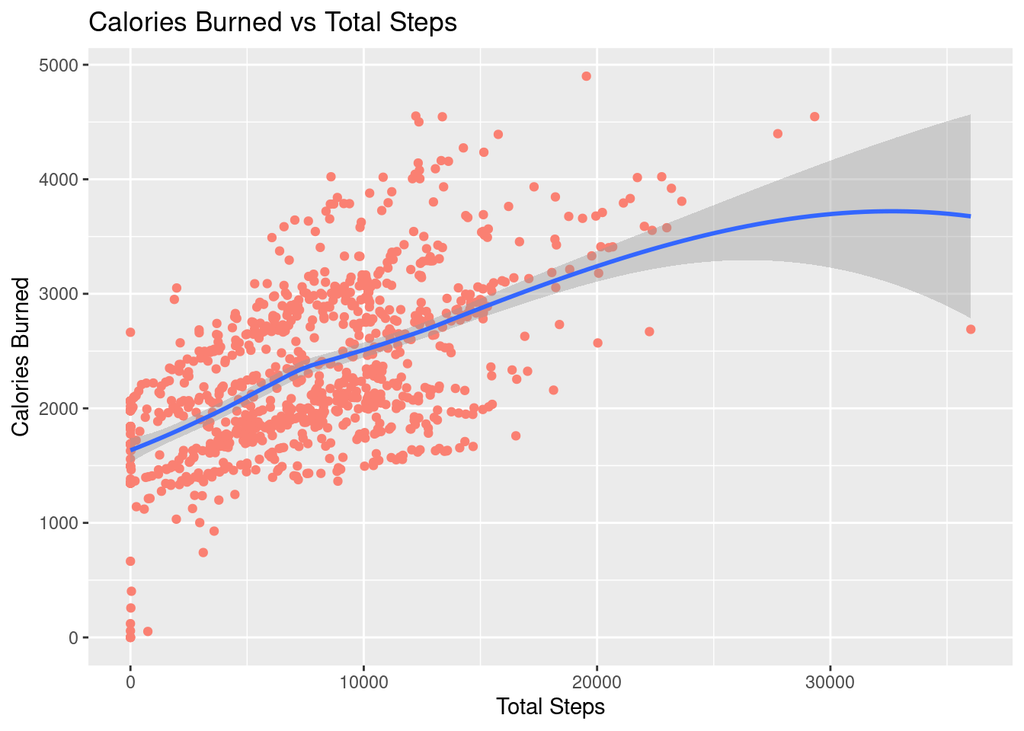

```r
ggplot(data=activity, aes(x=TotalSteps, y=Calories)) +
  geom_point(color="salmon") +
  geom_smooth() +
  labs(title = "Calories Burned vs Total Steps",x="Total Steps", y="Calories Burned")
```

* There is a positive correlation between Total Steps and Calories Burned, that means the more steps taken the more calories are burned.

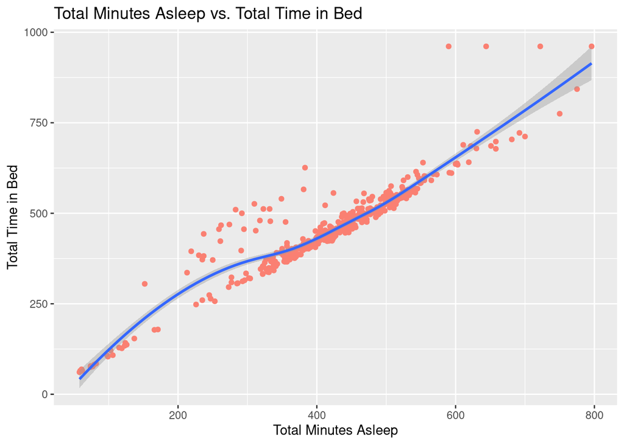

```r
ggplot(data=sleep, aes(x=TotalMinutesAsleep, y=TotalTimeInBed)) +
  geom_point(color="salmon") +
  geom_smooth() +
  labs(title="Total Minutes Asleep vs. Total Time in Bed",x="Total Minutes Asleep", y="Total Time in Bed")
```

* The relationship between Total Minutes Asleep and Total Time in Bed looks linear.

- Some of these data points spent a lot of time in bed, but didn’t actually sleep, and then a small batch that slept a whole bunch and spent more time in bed.

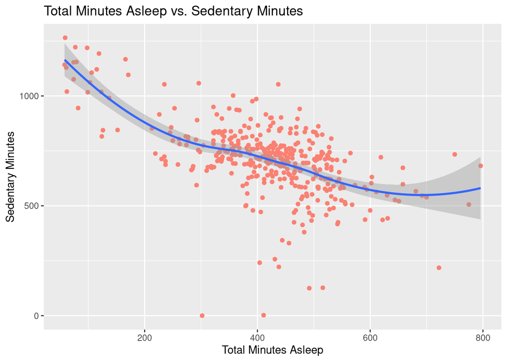

```r
ggplot(data=merged_data, aes(x=TotalMinutesAsleep, y=SedentaryMinutes)) +
  geom_point(color='salmon') +
  geom_smooth() +
  labs(title="Total Minutes Asleep vs. Sedentary Minutes", x="Total Minutes Asleep", y="Sedentary Minutes")
```

* Here we can see the negative relationship between Sedentary Minutes and Sleep time. If Bellabeat users want to improve their sleep, Bellabeat app can recommend reducing sedentary time.

# Recommendations for the business

**After analyzing FitBit Fitness Tracker Data, I found some insights that would help influence Bellabeat marketing strategy.**

*Based on the amount of steps taken and amount of calories burned, users appear to burn more calories with more steps. Average total steps per day are 7638 which is lower than the recommended amount of steps to receive health benefits according to the CDC research. They found that taking 8,000 steps per day was associated with a 51% lower risk for all-cause mortality (or death from all causes). Taking 12,000 steps per day was associated with a 65% lower risk compared with taking 4,000 steps. Bellabeat can encourage people to take at least 8 000 explaining the benefits for their health. Therefore, Bellabeat should encourage users to take more steps throughout the day. They could also offer app incentives, such as give users app credits for every 1000 steps, which can then be used to redeem prizes or vouchers.

*Bellabeat could incorporate a Sleep Score rating system that gives you a score based on the amount of time you were in bed vs the time you were asleep and Enable notifications in the morning to encourage activity if a user has spent an hour in bed awake.

**Thank you for reading, comments and feedback are always welcome!**